# Comparison of tracts after registration

## Intro

The idea is to try and compare the same FlyCircuit neurons after registration using CMTK (Cambridge) or FlyCircuit’s default pipeline (FCv1.2 online).

It is my impression going into this analysis that the mean and absolute dispersion after the Amira based registration in v1.2 is greater than for our standard CMTK registration. I would put this down to the use of single template brains that were acquired some time ago rather than an average brain, which has higher S/N and is more medial in its overall shape. See also Bogovic and Saalfeld

```r
library(flycircuit)
library(natverse)
```

```r
clear3d()
plot3d(dl2d.both, col=orig, colpal = c('cam'='cyan', fc='red'))
```

```
col argument does not not look like an R colour! Converting to factor!
Do this yourself to avoid this warning in future.
```

[figure not shown]

Let’s cut around 400

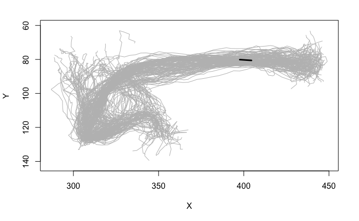

```r
plot3d(spines)
plc=plane_coefficients(mean_cent, mean_vec)
planes3d(plc[,1:3], d=plc[,'d'])
```

```r
clear3d()
make_centred_plane <- function(point, normal, scale = 1) {
  # find the two orthogonal vectors to this one
  uv = Morpho::tangentPlane(normal)
  uv = sapply(uv, "*", scale, simplify = F)
  qmesh3d(
  cbind(
  point + uv$z,
  point + uv$y,
  point - uv$z,
  point - uv$y
  ),
  homogeneous = F,
  indices = 1:4
  )
}
plane=make_centred_plane(mean_cent, mean_vec, scale=15)
plot3d(spines, col='grey')
shade3d(plane, col='red')
```

```r
intersections.cent=scale(intersections, center = T, scale = F)
d=sqrt(rowSums(intersections.cent^2))
mean(d)
```

```
[1] 2.542118
```

```r
spheres3d(intersections, col='red', rad=.5)
shade3d(plane, col='black')
plot3d(spines, col='grey')
```

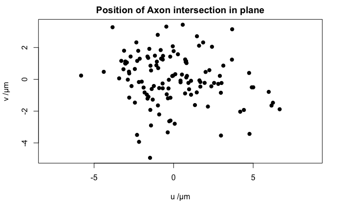

```r
uv = Morpho::tangentPlane(mean_vec)
# centre our points on mean
sp=scale(intersections, scale = F, center=T)
DotProduct=function(a,b) sum(a*b)
# find coordinates w.r.t. to our two basis vectors
xy=data.frame(u=apply(sp, 1, DotProduct, uv[[1]]),
           v=apply(sp, 1, DotProduct, uv[[2]]))
# maintain consist x-y aspect ratio
plot(xy, pch=19, asp=1, main = "Position of Axon intersection in plane",
     xlab="u /µm", ylab="v /µm")
```

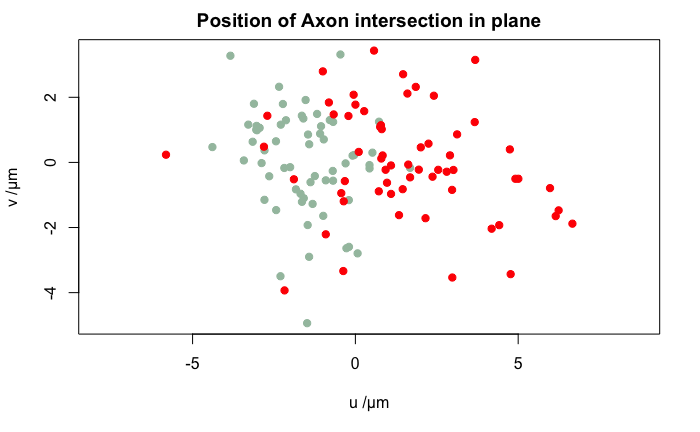

Let’s look at dispersion by registration origin

```r
t.test(devs$cam, devs$fc)
```

```
    Welch Two Sample t-test

data:  devs$cam and devs$fc
t = -3.0032, df = 97.152, p-value = 0.003398
alternative hypothesis: true difference in means is not equal to 0
95 percent confidence interval:
 -1.1420412 -0.2331945
sample estimates:
mean of x mean of y
 1.761904  2.449522
```

Let’s find a bunch of tract vectors near specific points.

```r
tract_vector_xyz <- function(n, xyz, thresh=10) {
  p=xyzmatrix(n)
  cent=scale(p, center = xyz, scale = F)
  d=sqrt(rowSums(cent^2))
  near=d<thresh
  pc=prcomp(p[near,, drop=FALSE], )
  c(colMeans(p[near,]), pc$rotation[,'PC1'])
}
tract_vectors <- function(x, xyz, ...) {
  tvsl=nlapply(spines, tract_vector_xyz, xyz=xyz, OmitFailures = T)
  tvs=do.call(rbind, tvsl)
  list(mean_cent=colMeans(tvs[,1:3]),
       mean_vec=colMeans(tvs[,4:6]))
}
```

Now to choose the specific points, let’s take one of the spines and choose evenly spaced points along it. First lets’s choose the most medial spine.

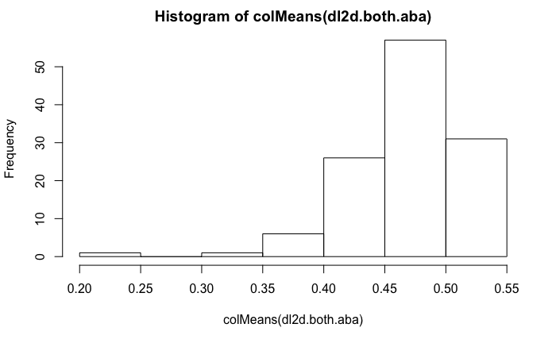

```r
dl2d.both.dps=dotprops(spines, k=5, resample=1)
dl2d.both.aba=nblast_allbyall(dl2d.both.dps, normalisation = 'mean')
hist(colMeans(dl2d.both.aba))
```

```r
best_neuron=names(which.max(colMeans(dl2d.both.aba)))
```

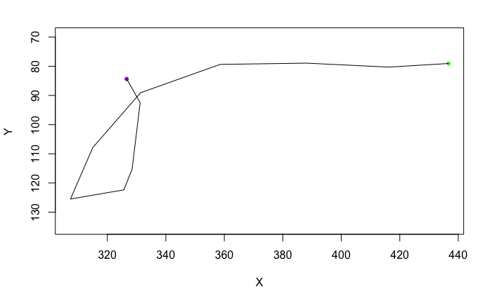

```r
pointstouse <- xyzmatrix(best.30)[3:(nvertices(best.30)-2), ]
pointstouse
```

```
            X         Y        Z
[1,] 328.4637 115.28222 27.90846
[2,] 325.6423 122.35958 27.60520
[3,] 307.3843 125.49382 45.96342
[4,] 315.0342 107.85699 68.14995
[5,] 331.3395  89.09016 82.64594
[6,] 358.5679  79.36380 85.18221
[7,] 388.1049  78.93367 82.67805
```

```r
planes=apply(pointstouse, 1, function(xyz) tract_vectors(spines, xyz=xyz, threshold=10))
head(planes, n = 3)
```

```
[[1]]
[[1]]$mean_cent
       X        Y        Z
327.6660 117.6042  28.2782

[[1]]$mean_vec
          X           Y           Z
-0.13365340  0.19929030  0.01638821


[[2]]
[[2]]$mean_cent
        X         Y         Z
323.94341 120.35619  29.18657

[[2]]$mean_vec
          X           Y           Z
-0.17164878  0.11435868  0.02350107


[[3]]
[[3]]$mean_cent
        X         Y         Z
308.13622 124.76910  44.84765

[[3]]$mean_vec
          X           Y           Z
-0.04516867 -0.11360055  0.30510254
```

Now let’s find the intersections on a plane for each of those locations

```r
project2plane <- function(data, mean_cent, mean_vec) {
  plc=plane_coefficients(mean_cent, mean_vec)
  intersections=t(sapply(data, intersect_plane, plc, closestpoint=mean_cent))
  uv = Morpho::tangentPlane(mean_vec)
  # centre our points on mean
  sp=scale(intersections, scale = F, center=T)
  DotProduct=function(a,b) sum(a*b)
# find coordinates w.r.t. to our two basis vectors
  xy=data.frame(u=apply(sp, 1, DotProduct, uv[[1]]),
           v=apply(sp, 1, DotProduct, uv[[2]]))
  xy
}

projected=sapply(planes, function(plc) project2plane(spines, plc$mean_cent,plc$mean_vec), simplify = F)
resdf=dplyr::bind_rows(projected, .id = 'pos')
resdf$name=rep(names(spines), length(projected))
resdf$orig=rep(spines[,'orig'], length(projected))
```

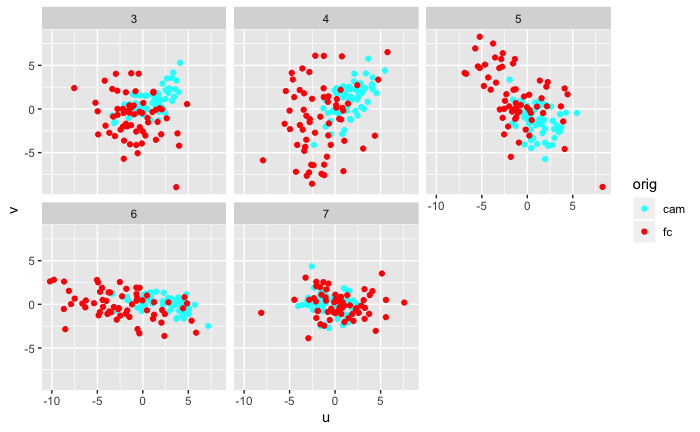

```r
library(ggplot2)
qplot(u,v, data=subset(resdf, pos%in%3:7), col=orig)+facet_wrap(~pos)+
  scale_color_manual(values = c('cam'='cyan', fc='red'))
```

Let’s look at distance from centroid at each of those points

| pos | orig | md |
| --- | --- | --- |
| 3 | cam | 1.929831 |
| 3 | fc | 2.968522 |
| 4 | cam | 2.091827 |
| 4 | fc | 4.237263 |
| 5 | cam | 2.020204 |
| 5 | fc | 3.737310 |
| 6 | cam | 2.058596 |
| 6 | fc | 3.564199 |
| 7 | cam | 1.849523 |
| 7 | fc | 2.573278 |

Now we can plot the mean dispersion at those different locations

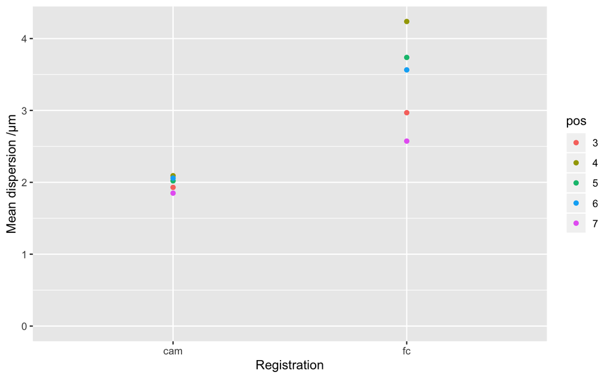

```r
qplot(factor(orig), md, data=resdf3, col=pos, ylim=c(0,NA),
      ylab='Mean dispersion /µm', xlab='Registration')
```

```r
resdf3.wide=tidyr::pivot_wider(resdf3, names_from = 'orig', values_from='md')
resdf3.wide
```

| pos | cam | fc |
| --- | --- | --- |
| 3 | 1.929831 | 2.968522 |
| 4 | 2.091827 | 4.237263 |
| 5 | 2.020204 | 3.737310 |
| 6 | 2.058596 | 3.564199 |
| 7 | 1.849523 | 2.573278 |

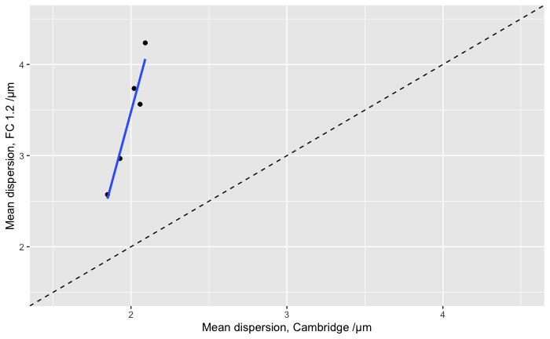

```r
qplot(cam, fc, data=resdf3.wide, xlim=c(1.5,4.5), ylim=c(1.5,4.5),
      xlab='Mean dispersion, Cambridge /µm', ylab='Mean dispersion, FC 1.2 /µm')+
  geom_abline(slope=1, lty=2)+
  geom_smooth(method = 'lm', se = F)
```

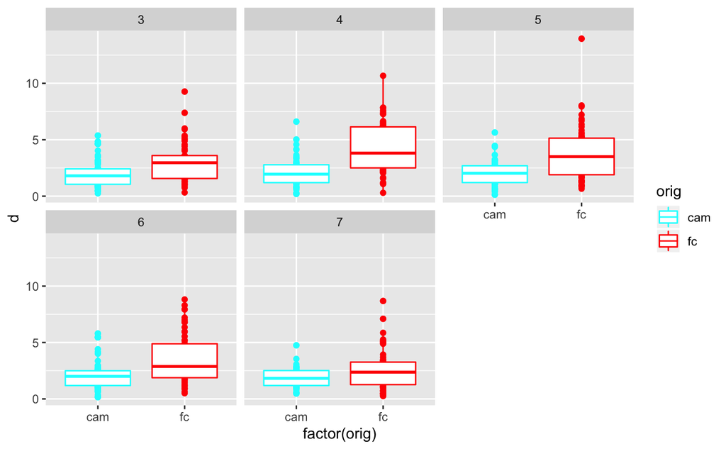

```r
qplot(factor(orig), d, data=resdf2, col=orig) +
  scale_colour_manual(values = c('cam'='cyan', fc='red'))+
  facet_wrap(~pos)+geom_boxplot()
```

```r
plot_centred_plane <- function(plc, scale=1, ...) {
  plane=make_centred_plane(plc$mean_cent, plc$mean_vec, scale=scale)
  shade3d(plane, ...)
}
```

```r
sapply(planes[-(1:2)], plot_centred_plane, scale=15, col='grey')
```

```
quads quads quads quads quads
 2049  2050  2051  2052  2053
```